# Tugas Pertemuan 2 Metode Peramalan Deret Waktu

Muhammad Rizky Fajar

## Dataset

Dataset dapat diakses secara keseluruhan pada laman https://www.kaggle.com/datasets/theforcecoder/wind-power-forecasting. Dateset tersebut merupakan data dari suatu kincir angin tertentu yang mengandung berbagai fitur cuaca, turbin dan rotor. Data telah direkam sejak Januari 2018 hingga Maret 2020 dengan interval waktu 10 menit.

Penelitian ini menggunakan 165 baris data, mulai dari baris data pada 2020-03-23 23:40:00+00:00 hingga 2020-03-25 03:00:00+00:00. Peubah yang digunakan merupakan peubah “ActivePower” yang berfungsi sebagai peubah tak bebas (y) serta peubah “BearingShaftTemperature”, “GeneratorRPM”, “MainBoxTemperature”, dan “WindSpeed” yang berfungsi sebagai peubah bebas (x).

## Impor Data

```r
library(rio)
df <- import("https://raw.githubusercontent.com/mhdrfajar/mpdw/main/Pertemuan%202/data_turbin.csv")
colnames(df)[colnames(df)=="ActivePower"] = "y"
colnames(df)[colnames(df)=="BearingShaftTemperature"] = "x1"
colnames(df)[colnames(df)=="GeneratorRPM"] = "x2"
colnames(df)[colnames(df)=="MainBoxTemperature"] = "x3"
colnames(df)[colnames(df)=="WindSpeed"] = "x4"
summary(df)
```

```
##        y                  x1              x2                 x3
##  Min.   :  -8.528   Min.   :39.59   Min.   :   2.587   Min.   :35.05
##  1st Qu.:  92.429   1st Qu.:41.68   1st Qu.:1026.323   1st Qu.:37.59
##  Median : 245.306   Median :42.71   Median :1038.228   Median :40.33
##  Mean   : 345.406   Mean   :43.37   Mean   : 965.358   Mean   :41.35
##  3rd Qu.: 552.864   3rd Qu.:44.97   3rd Qu.:1217.363   3rd Qu.:45.84
##  Max.   :1228.060   Max.   :48.37   Max.   :1589.451   Max.   :48.73
##        x4
##  Min.   :1.939
##  1st Qu.:3.855
##  Median :4.781
##  Mean   :4.876
##  3rd Qu.:6.026
##  Max.   :7.989
```

```r
df
```

```
##               y       x1          x2       x3       x4
## 1     -4.319298 43.08728  682.182964 36.50781 3.064411
## 2     48.312571 42.70117  664.044668 37.24999 3.662826
## 3    119.955163 42.78981 1030.035300 36.49374 4.047242
## 4    130.370217 42.77419 1030.068850 35.96443 4.445589
## 5    152.941116 42.71203 1029.947278 35.71875 4.414631
## 6    216.871659 42.64979 1030.107122 35.57031 4.905278
## 7    256.402430 42.58464 1034.696833 35.49751 4.938405
## 8    322.042399 42.51303 1070.155270 35.48489 4.993100
## 9    501.023631 42.53421 1172.576756 35.46644 5.902895
## 10   463.085382 42.46789 1151.245860 35.52778 5.709237
## 11   458.300223 42.41256 1129.317738 35.66071 5.644728
## 12   465.620732 42.40287 1154.848011 35.76389 5.564716
## 13   361.246373 42.33057 1072.958420 35.90278 5.284772
## 14   367.468576 42.21890 1084.168250 36.02075 5.276779
```

[output cut: 151 more lines]

```r
y = df$y
x1 = df$x1
x2 = df$x2
x3 = df$x3
x4 = df$x4
```

## Pemanggilan *Packages*

```r
library(dplyr)
library(GGally)
```

```r
library(ggplot2)
library(corrplot)
library(TTR)
library(forecast)
library(olsrr)
library(lmtest) #digunakan untuk uji formal pendeteksian autokorelasi
library(orcutt) #untuk membuat model regresi Cochrane-Orcutt
library(HoRM) #untuk membuat model regresi Hildreth-Lu
```

## Eksplorasi Data

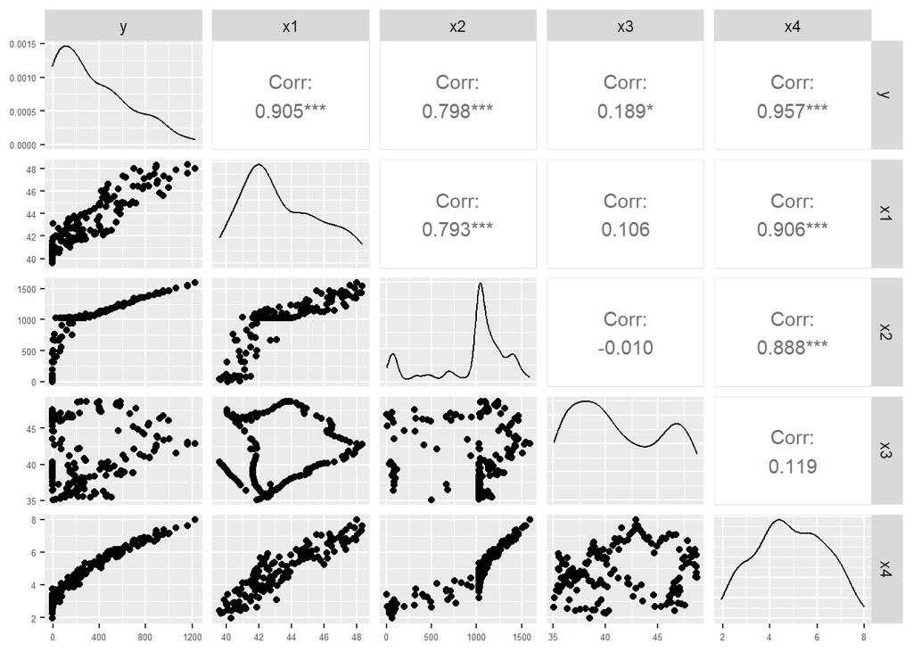

```r
# Menghasilkan plot ggpairs
plot <- ggpairs(df[sapply(df, is.numeric)])

# Mengatur ukuran font pada semua elemen
plot <- plot + theme(
  axis.text = element_text(size = 5),
  axis.title = element_text(size = 5),
  legend.text = element_text(size = 5)
)

# Tampilkan gambar
print(plot)
```

## Model Regresi Linear Berganda OLS

```r
model <- lm(y ~ x1+x2+x3+x4, df)
summary(model)
```

```
##
## Call:
## lm(formula = y ~ x1 + x2 + x3 + x4, data = df)
##
## Residuals:
##      Min       1Q   Median       3Q      Max
## -172.064  -58.753   -1.762   41.333  225.365
##
## Coefficients:
##               Estimate Std. Error t value Pr(>|t|)
## (Intercept) -1.809e+03  2.366e+02  -7.643 1.84e-12 ***
## x1           2.636e+01  6.286e+00   4.193 4.54e-05 ***
## x2          -1.575e-01  3.393e-02  -4.641 7.18e-06 ***
## x3           3.801e+00  1.491e+00   2.549   0.0117 *
## x4           2.063e+02  1.373e+01  15.024  < 2e-16 ***
## ---
## Signif. codes:  0 '***' 0.001 '**' 0.01 '*' 0.05 '.' 0.1 ' ' 1
##
## Residual standard error: 78.56 on 160 degrees of freedom
## Multiple R-squared:  0.9376, Adjusted R-squared:  0.936
## F-statistic: 600.5 on 4 and 160 DF,  p-value: < 2.2e-16
```

## Model Regresi Terbaik

```r
bestsubset <- ols_step_best_subset(model)
bestsubset
```

```
##  Best Subsets Regression
## --------------------------
## Model Index    Predictors
## --------------------------
##      1         x4
##      2         x2 x4
##      3         x1 x2 x4
##      4         x1 x2 x3 x4
## --------------------------
##
##                                                          Subsets Regression Summary
## ---------------------------------------------------------------------------------------------------------------------------------------------
##                        Adj.        Pred
## Model    R-Square    R-Square    R-Square     C(p)         AIC         SBIC          SBC           MSEP           FPE         HSP       APC
## ---------------------------------------------------------------------------------------------------------------------------------------------
##   1        0.9154      0.9149      0.9123    55.6918    1959.2891    1489.9713    1968.6069    1353737.9798    8303.9132    50.6448    0.0867
##   2        0.9283      0.9274      0.9249    24.6386    1933.9805    1465.1012    1946.4043    1154370.4227    7123.1098    43.4529    0.0743
##   3        0.9350      0.9338      0.9315     9.4995    1919.8142    1451.4923    1935.3440    1053173.8889    6537.1011    39.8899    0.0682
##   4        0.9376      0.9360      0.9334     5.0000    1915.2442    1447.3051    1933.8799    1018427.3401    6358.5841    38.8149    0.0664
## ---------------------------------------------------------------------------------------------------------------------------------------------
## AIC: Akaike Information Criteria
##  SBIC: Sawa's Bayesian Information Criteria
##  SBC: Schwarz Bayesian Criteria
##  MSEP: Estimated error of prediction, assuming multivariate normality
##  FPE: Final Prediction Error
##  HSP: Hocking's Sp
##  APC: Amemiya Prediction Criteria
```

Model terbaik dengan kriteria *AIC* terkecil adalah model awal dengan peubah bebas $x_1$, $x_2$, $x_3$, dan $x_4$

## Pengecekan Multikolinearitas

```r
# Pengecekan pertama
library(car)
vif(model)
```

```
##        x1        x2        x3        x4
##  5.630851  5.086716  1.084872 10.374578
```

Dengan menggunakan metode *VIF* yang menduga adanya multikolinearitas ketika *VIF* > 10, diperoleh bahwa terdapat multikolinearitas pada peubah $x_4$. Sehingga peubah $x_4$ dikeluarkan dari model.

```r
#Mengeluarkan variabel x4 dari model awal
model2 = lm(y ~ x1+x2+x3, df)
summary(model2)
```

```
##
## Call:
## lm(formula = y ~ x1 + x2 + x3, data = df)
##
## Residuals:
##      Min       1Q   Median       3Q      Max
## -229.049  -94.324   -2.644   77.955  316.005
##
## Coefficients:
##               Estimate Std. Error t value Pr(>|t|)
## (Intercept) -4.242e+03  2.671e+02 -15.882  < 2e-16 ***
## x1           9.346e+01  6.845e+00  13.653  < 2e-16 ***
## x2           1.876e-01  3.866e-02   4.852 2.87e-06 ***
## x3           8.533e+00  2.256e+00   3.783 0.000218 ***
## ---
## Signif. codes:  0 '***' 0.001 '**' 0.01 '*' 0.05 '.' 0.1 ' ' 1
##
## Residual standard error: 121.6 on 161 degrees of freedom
## Multiple R-squared:  0.8495, Adjusted R-squared:  0.8466
## F-statistic: 302.8 on 3 and 161 DF,  p-value: < 2.2e-16
```

```r
# Pengecekan kedua
vif(model2)
```

```
##       x1       x2       x3
## 2.787586 2.756368 1.036472
```

Setelah membuang peubah $x_4$ dari model awal, didapatkan model terbaru dengan *VIF* < 10 pada setiap peubah bebasnya. Artinya tidak terdapat multikolinearitas pada peubah bebas di model yang terbaru.

## Uji Normalitas

$H_0$: Sisaan menyebar normal

$H_1$: Sisaan tidak menyebar normal

```r
# Kolmogorov-Smirnov test
ks.test(model2$residuals, "pnorm", mean=mean(model2$residuals), sd=sd(model2$residuals))
```

```
##
##  Asymptotic one-sample Kolmogorov-Smirnov test
##
## data:  model2$residuals
## D = 0.047847, p-value = 0.8444
## alternative hypothesis: two-sided
```

```r
# Shapiro-Wilk normality test
library(car)
shapiro.test(model2$residuals)
```

```
##
##  Shapiro-Wilk normality test
##
## data:  model2$residuals
## W = 0.98375, p-value = 0.05071
```

Hasil *Kolmogorov-Smirnov test* dan *Shapiro-Wilk normality test* menunjukkan bahwa *p-value* > $\alpha$=5% sehingga tak tolak $H_0$ atau tidak cukup bukti untuk menyatakan bahwa sisaan tidak menyebar normal. Dengan kata lain, asumsi normalitas sisaan terpenuhi.

## Uji Asumsi GAUSS MARKOV

### Nilai harapan sisaan sama dengan nol

$H_0$: Nilai harapan sisaan sama dengan nol

$H_1$: Nilai harapan sisaan tidak sama dengan nol

```r
t.test(model2$residuals,
       mu = 0,
       conf.level = 0.95)
```

```
##
##  One Sample t-test
##
## data:  model2$residuals
## t = -2.2058e-16, df = 164, p-value = 1
## alternative hypothesis: true mean is not equal to 0
## 95 percent confidence interval:
##  -18.51961  18.51961
## sample estimates:
##     mean of x
## -2.068884e-15
```

Hasil uji t menunjukkan bahwa *p-value* > $\alpha$=5% sehingga tak tolak $H_0$ atau tidak cukup bukti untuk menyatakan bahwa nilai harapan sisaan tidak sama dengan nol. Dengan kata lain, asumsi nilai harapan sisaan sama dengan nol terpenuhi.

### Ragam sisaan homogen

$H_0$: ragam sisaan homogen

$H_1$: ragam sisaan tidak homogen

```r
# Breusch-Pagan test
library(lmtest)
bptest(model2)
```

```
##
##  studentized Breusch-Pagan test
##
## data:  model2
## BP = 12.172, df = 3, p-value = 0.006818
```

```r
# Non-constant Variance Score (NCV) Test
library(car)
ncvTest(model2)
```

```
## Non-constant Variance Score Test
## Variance formula: ~ fitted.values
## Chisquare = 5.899949, Df = 1, p = 0.015141
```

Hasil *Breusch-Pagan test* dan *Non-constant Variance Score (NCV) test* menunjukkan bahwa *p-value* < $\alpha$=5% sehingga tolak $H_0$ atau cukup bukti untuk menyatakan bahwa ragam sisaan tidak homogen. Dengan kata lain, asumsi ragam sisaan homogen tidak terpenuhi.

### Sisaan saling bebas

$H_0$: tidak ada autokorelasi (sisaan saling bebas)

$H_1$: ada autokorelasi (sisaan tidak saling bebas)

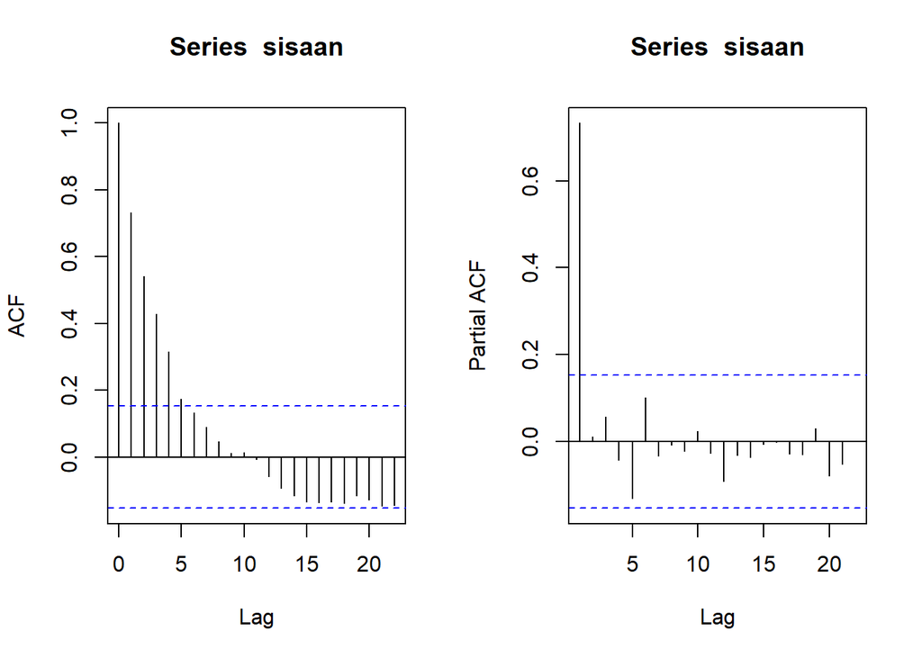

```r
#ACF dan PACF identifikasi autokorelasi
sisaan <- residuals(model2)
par(mfrow = c(1,2))
acf(sisaan)
pacf(sisaan)
```

```r
# Runs Test
library(randtests)
runs.test(model2$residuals)
```

```
##
##  Runs Test
##
## data:  model2$residuals
## statistic = -7.9894, runs = 32, n1 = 82, n2 = 82, n = 164, p-value =
## 1.356e-15
## alternative hypothesis: nonrandomness
```

```r
# Durbin Watson Test
library(lmtest)
dwtest(model2)
```

```
##
##  Durbin-Watson test
##
## data:  model2
## DW = 0.49862, p-value < 2.2e-16
## alternative hypothesis: true autocorrelation is greater than 0
```

```r
# Breusch-Godfrey Test
bgtest(model2)
```

```
##
##  Breusch-Godfrey test for serial correlation of order up to 1
##
## data:  model2
## LM test = 90.115, df = 1, p-value < 2.2e-16
```

Berdasarkan plot ACF dan PACF, terlihat terdapat plot yang berada di luar rentang batas yang artinya dapat diperoleh kesimpulan bahwa tolak $H_0$ atau cukup bukti untuk menyatakan bahwa terdapat autokorelasi. Kesimpulan tersebut juga didukung oleh hasil uji formal menggunakan *Runs test*, *Durbin Watson test*, dan *Breusch-Godfrey test* yang menghasilkan *p-value* < $\alpha$=5%. Oleh karena itu, diperlukan penangan autokorelasi. Penanganan yang akan digunakan menggunakan dua metode, yaitu *Cochrane-Orcutt* dan *Hildret-Lu*.

## Penanganan Autokorelasi

### Metode Cochrane-Orcutt

Penanganan metode Cochrane-Orcutt dapat dilakukan dengan bantuan packages Orcutt pada aplikasi `R` maupun secara manual. Berikut ini ditampilkan cara menggunakan bantuan `library` *packages* `Orcutt`.

```r
#Penanganan Autokorelasi Cochrane-Orcutt
modelCO<-cochrane.orcutt(model2)
modelCO
```

```
## Cochrane-orcutt estimation for first order autocorrelation
##
## Call:
## lm(formula = y ~ x1 + x2 + x3, data = df)
##
##  number of interaction: 6
##  rho 0.759635
##
## Durbin-Watson statistic
## (original):    0.49862 , p-value: 1.435e-23
## (transformed): 2.01669 , p-value: 4.874e-01
##
##  coefficients:
##  (Intercept)           x1           x2           x3
## -3808.470781    81.579341     0.260589     9.037010
```

Hasil keluaran model setelah dilakukan penanganan adalah sebagai berikut.
$$y_i=-3808.470781+81.5793415x_1+0.260589x_2+9.037010x_3$$
Hasil juga menunjukkan bahwa nilai *p-value* > 0.05, artinya belum cukup bukti menyatakan bahwa sisaan terdapat autokorelasi pada taraf nyata 5%. Untuk nilai $ρ ̂$ optimum yang digunakan adalah $0.7596351$. Nilai tersebut dapat diketahui dengan *syntax* berikut.

```r
#Rho optimum
rho<- modelCO$rho
rho
```

```
## [1] 0.7596351
```

Selanjutnya akan dilakukan transformasi secara manual dengan syntax berikut ini.

```r
#Transformasi Manual
y.trans<- y[-1]-y[-165]*rho
x1.trans<- x1[-1]-x1[-165]*rho
x2.trans<- x2[-1]-x2[-165]*rho
x3.trans<- x3[-1]-x3[-165]*rho
modelCOmanual<- lm(y.trans~x1.trans+x2.trans+x3.trans)
summary(modelCOmanual)
```

```
##
## Call:
## lm(formula = y.trans ~ x1.trans + x2.trans + x3.trans)
##
## Residuals:
##      Min       1Q   Median       3Q      Max
## -228.721  -49.120    4.922   40.050  222.875
##
## Coefficients:
##               Estimate Std. Error t value Pr(>|t|)
## (Intercept) -915.42274  129.77232  -7.054 4.96e-11 ***
## x1.trans      81.57934   12.10018   6.742 2.69e-10 ***
## x2.trans       0.26059    0.04019   6.485 1.06e-09 ***
## x3.trans       9.03701    5.94009   1.521     0.13
## ---
## Signif. codes:  0 '***' 0.001 '**' 0.01 '*' 0.05 '.' 0.1 ' ' 1
##
## Residual standard error: 79.49 on 160 degrees of freedom
## Multiple R-squared:  0.5297, Adjusted R-squared:  0.5209
## F-statistic: 60.07 on 3 and 160 DF,  p-value: < 2.2e-16
```

```r
#Mencari Penduga Koefisien Regresi setelah Transformasi ke Persamaan Awal
b0bintang <- modelCOmanual$coefficients[1]
b0 <- b0bintang/(1-rho)
b1 <- modelCOmanual$coefficients[2:4]
b0
```

```
## (Intercept)
##   -3808.471
```

```r
b1
```

```
##   x1.trans   x2.trans   x3.trans
## 81.5793414  0.2605891  9.0370098
```

Hasil perhitungan koefisien regresi tersebut akan menghasilkan hasil yang sama dengan model yang dihasilkan menggunakan *packages*.

### Metode Hildreth-Lu

Penanganan kedua adalah menggunakan metode Hildreth-Lu. Metode ini akan mencari nilai *SSE* terkecil dan dapat dicari secara manual maupun menggunakan packages. Jika menggunakan packages, gunakan `library` *packages* `HORM`.

```r
#Penanganan Autokorelasi Hildreth lu
# Hildreth-Lu
hildreth.lu.func<- function(r, model2){
  x1 <- model.matrix(model2)[,2]
  x2 <- model.matrix(model2)[,3]
  x3 <- model.matrix(model2)[,4]
  y <- model.response(model.frame(model2))
  n <- length(y)
  t <- 2:n
  y <- y[t]-r*y[t-1]
  x1 <- x1[t]-r*x1[t-1]
  x2 <- x2[t]-r*x2[t-1]
  x3 <- x3[t]-r*x3[t-1]

  return(lm(y~x1+x2+x3))
}

#Pencariab rho yang meminimumkan SSE
r <- c(seq(0.1,0.9, by= 0.1))
tab <- data.frame("rho" = r, "SSE" = sapply(r, function(i){deviance(hildreth.lu.func(i, model))}))
round(tab, 4)
```

```
##   rho     SSE
## 1 0.1 2001860
## 2 0.2 1723486
## 3 0.3 1491421
## 4 0.4 1305301
## 5 0.5 1164714
## 6 0.6 1069344
## 7 0.7 1019207
## 8 0.8 1014792
## 9 0.9 1056348
```

Pertama-tama akan dicari di mana kira-kira $ρ$ yang menghasilkan *SSE* minimum. Pada hasil di atas terlihat $ρ$ minimum ketika 0.8. Namun, hasil tersebut masih kurang teliti sehingga akan dicari kembali $ρ$ yang lebih optimum dengan ketelitian yang lebih. Jika sebelumnya jarak antar $ρ$ yang dicari adalah 0.1, kali ini jarak antar $ρ$ adalah 0.0001 dan dilakukan pada selang 0.7 sampai dengan 0.9.

```r
#Rho optimal di sekitar 0.4
rOpt <- seq(0.7,0.9, by= 0.0001)
tabOpt <- data.frame("rho" = rOpt, "SSE" = sapply(rOpt, function(i){deviance(hildreth.lu.func(i, model))}))
head(tabOpt[order(tabOpt$SSE),])
```

```
##        rho     SSE
## 597 0.7596 1011025
## 598 0.7597 1011025
## 596 0.7595 1011025
## 599 0.7598 1011025
## 595 0.7594 1011025
## 600 0.7599 1011025
```

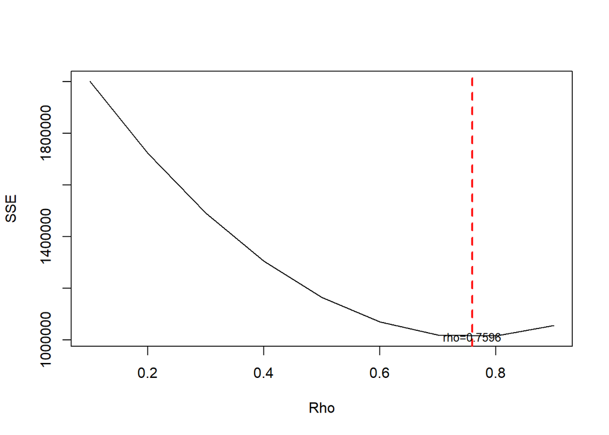

```r
#Grafik SSE optimum
par(mfrow = c(1,1))
plot(tab$SSE ~ tab$rho , type = "l", xlab = "Rho", ylab = "SSE")
abline(v = tabOpt[tabOpt$SSE==min(tabOpt$SSE),"rho"], lty = 2, col="red",lwd=2)
text(x=0.7596   , y=1011025, labels = "rho=0.7596", cex = 0.8)
```

Perhitungan yang dilakukan aplikasi `R` menunjukkan bahwa nilai $ρ$ optimum, yaitu saat *SSE* terkecil terdapat pada nilai $ρ=0.7596$. Hal tersebut juga ditunjukkan pada plot. Selanjutnya, model dapat didapatkan dengan mengevaluasi nilai $ρ$ ke dalam fungsi `hildreth.lu.func`, serta dilanjutkan dengan pengujian autokorelasi dengan uji Durbin-Watson. Namun, setelah pengecekan tersebut tidak lupa koefisien regresi tersebut digunakan untuk transformasi balik. Persamaan hasil transformasi itulah yang menjadi persamaan sesungguhnya.

```r
#Model terbaik
modelHL <- hildreth.lu.func(0.7596, model2)
summary(modelHL)
```

```
##
## Call:
## lm(formula = y ~ x1 + x2 + x3)
##
## Residuals:
##      Min       1Q   Median       3Q      Max
## -228.718  -49.123    4.921   40.052  222.868
##
## Coefficients:
##               Estimate Std. Error t value Pr(>|t|)
## (Intercept) -915.56158  129.77612  -7.055 4.93e-11 ***
## x1            81.58018   12.09898   6.743 2.68e-10 ***
## x2             0.26058    0.04019   6.484 1.06e-09 ***
## x3             9.03673    5.93929   1.522     0.13
## ---
## Signif. codes:  0 '***' 0.001 '**' 0.01 '*' 0.05 '.' 0.1 ' ' 1
##
## Residual standard error: 79.49 on 160 degrees of freedom
## Multiple R-squared:  0.5298, Adjusted R-squared:  0.5209
## F-statistic: 60.08 on 3 and 160 DF,  p-value: < 2.2e-16
```

```r
#Transformasi Balik
cat("y = ", coef(modelHL)[1]/(1-0.7596), "+", coef(modelHL)[2],"x1","+", coef(modelHL)[3],"x2","+", coef(modelHL)[4],"x3", sep = "")
```

```
## y = -3808.492+81.58018x1+0.2605841x2+9.036731x3
```

Setelah dilakukan tranformasi balik, didapatkan model dengan metode Hildreth-Lu sebagai berikut.
$$y_i=-3808.492+81.58018x_1+0.2605841x_2+9.036731x_3$$

```r
#Deteksi autokorelasi
dwtest(modelHL)
```

```
##
##  Durbin-Watson test
##
## data:  modelHL
## DW = 2.0166, p-value = 0.4872
## alternative hypothesis: true autocorrelation is greater than 0
```

Hasil uji *Durbin-Watson* juga menunjukkan bawah nilai *p-value* sebesar $0.4872$, di mana *p-value* > $\alpha$=5%. Artinya tak tolak $H_0$ atau belum cukup bukti menyatakan bahwa terdapat autokorelasi dengan metode *Hildreth-Lu* pada taraf nyata 5%.

Terakhir, akan dibandingkan nilai *SSE* dari ketiga metode (metode awal, metode *Cochrane-Orcutt*, dan *Hildreth-Lu*).

```r
#Perbandingan
sseModelawal <- anova(model2)$`Sum Sq`[-(1:3)]
sseModelCO <- anova(modelCOmanual)$`Sum Sq`[-(1:3)]
sseModelHL <- anova(modelHL)$`Sum Sq`[-(1:3)]
mseModelawal <- sseModelawal/length(y)
mseModelCO <- sseModelCO/length(y)
mseModelHL <- sseModelHL/length(y)
akurasi <- matrix(c(sseModelawal,sseModelCO,sseModelHL,
                    mseModelawal,mseModelCO,mseModelHL),nrow=2,ncol=3,byrow = T)
colnames(akurasi) <- c("Model Awal", "Model Cochrane-Orcutt", "Model Hildreth-Lu")
row.names(akurasi) <- c("SSE","MSE")
akurasi
```

```
##     Model Awal Model Cochrane-Orcutt Model Hildreth-Lu
## SSE 2380466.80           1011025.320       1011025.323
## MSE   14427.07              6127.426          6127.426
```

Berdasarkan hasil tersebut dapat diketahui bahwa hasil penanganan autokorelasi dengan metode *Cochrane-Orcutt* dan *Hildreth-Lu* memiliki *SSE* yang hampir sama, metode *Cochrane-Orcutt* menghasilkan *SSE* sebesar $1011025.320$ sedangkan metode *Hildreth-Lu* menghasilkan *SSE* sebesar $1011025.323$. Kedua metode tersebut menghasilkan *SSE* yang lebih baik dibandingkan model awal ketika autokorelasi masih terjadi, yaitu sebesar $2380466.80$.

## Simpulan

Autokorelasi yang terdapat pada data Wind Power Forecasting terjadi akibat adanya korelasi di antara unsur penyusunnya. Indikator data Wind Power Forecasting yang erat kaitannya dengan pergerakan angin yang berbeda-beda sesuai dengan periode waktu tertentu sangat rawan menjadi penyebab adanya autokorelasi. Adanya autokorelasi menyebabkan model regresi kurang baik karena akan meningkatkan galatnya. Autokorelasi dapat dideteksi secara eksploratif melalui plot sisaan, ACF, dan PACF, serta dengan uji formal Runs, Durbin-Watson, dan Breusch-Godfrey. Namun, autokorelasi tersebut dapat ditangani dengan metode Cochrane-Orcutt dan Hildreth-Lu. Kedua metode menghasilkan nilai *SSE* yang hampir sama, artinya keduanya baik untuk digunakan.